# EXECUTIVE STRATEGY REPORT DATASET: 126,130 STEAM PC GAMES

## Steam Video Games: 15 Core Strategic Questions & Findings

### A Non-Technical Business Briefing for Studio Leadership, Publishers, and Investors

```python
import warnings
warnings.filterwarnings('ignore', category=FutureWarning)

import pandas as pd
import numpy as np
import matplotlib.pyplot as plt
import seaborn as sns
import plotly.express as px
import plotly.graph_objects as go
from scipy import stats

# Global styling
plt.style.use('seaborn-v0_8-darkgrid')
sns.set_palette('muted')
plt.rcParams['font.size'] = 11
plt.rcParams['figure.titlesize'] = 14
plt.rcParams['figure.figsize'] = (12, 6)

# Load data
df = pd.read_csv('../data/steam_games_cleaned.csv', low_memory=False)
df['review_score_pct'] = df['review_score_pct'] * 100

# Basic cleaning/setup for EDA
df['release_year'] = pd.to_datetime(df['release_date'], errors='coerce').dt.year
# Filter out weird early years
df = df[(df['release_year'] >= 2010) & (df['release_year'] <= 2025)].copy()

# Ensure numeric columns
num_cols = ['price', 'highest_estimate_owner', 'review_score_pct', 'recommendations', 'peak_ccu', 'languages_count', 'patforms_count', 'playtime_engagment_ratio', 'value_score']
for col in num_cols:
    df[col] = pd.to_numeric(df[col], errors='coerce')

# Filter for main genres to reduce noise in charts
main_genres = df['primary_genre'].value_counts()
main_genres_list = main_genres[main_genres > 1000].index.tolist()
df_main = df[df['primary_genre'].isin(main_genres_list)].copy()
```

## Section 1: Pricing & Value Patterns

### Question 1: Which genres have the highest average price? Which are cheapest?

**What this visual shows**: Comparison of Average (Mean) and Middle (Median) game prices across top genres.

**Stakeholder Takeaway**: Benchmark base game pricing against your specific genre peers rather than general platform averages.

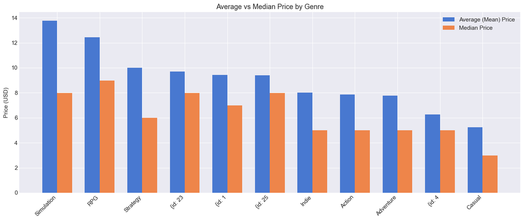

```python
# Question 1: Genres by Price
q1_df = df_main.groupby('primary_genre')['price'].agg(['mean', 'median']).sort_values('mean', ascending=False).reset_index()

fig, ax = plt.subplots(figsize=(14, 6))
x = np.arange(len(q1_df))
width = 0.35

ax.bar(x - width/2, q1_df['mean'], width, label='Average (Mean) Price')
ax.bar(x + width/2, q1_df['median'], width, label='Median Price')

ax.set_ylabel('Price (USD)')
ax.set_title('Average vs Median Price by Genre')
ax.set_xticks(x)
ax.set_xticklabels(q1_df['primary_genre'], rotation=45, ha='right')
ax.legend()
plt.tight_layout()
plt.show()
```

### Question 2: Is there a relationship between price and quality score? (Do expensive games score better?)

**What this visual shows**: Every dot is a game with its price on the bottom and user review score on the left, with an overall red trendline.

**Stakeholder Takeaway**: Higher development spend on graphics does not guarantee player satisfaction. Invest in bug-free mechanics and engaging gameplay.

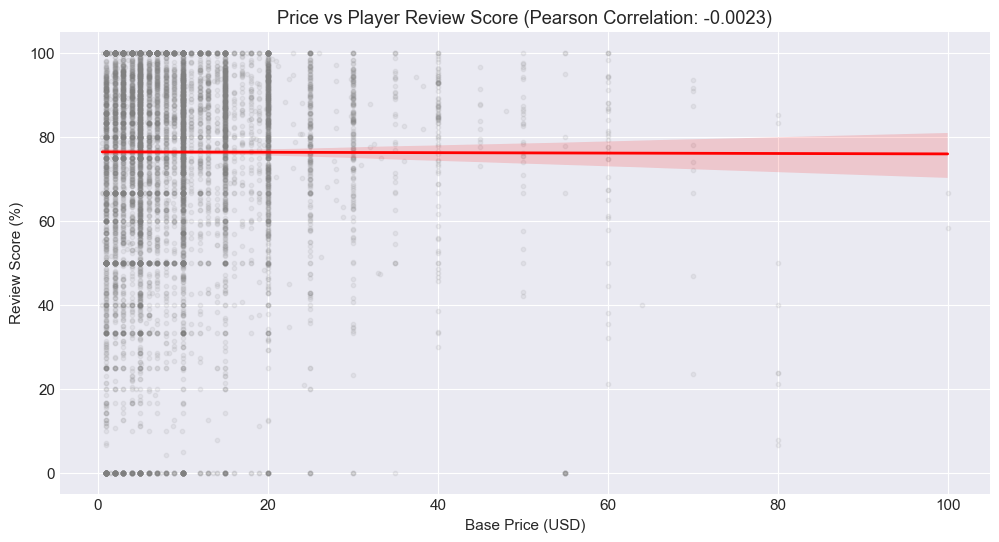

```python
# Question 2: Price vs Quality
plt.figure(figsize=(12, 6))
# Sample data to avoid overplotting millions of dots
sample_df = df_main.dropna(subset=['price', 'review_score_pct'])
sample_df = sample_df[(sample_df['price'] > 0) & (sample_df['price'] < 100)].sample(min(10000, len(sample_df)))

sns.regplot(data=sample_df, x='price', y='review_score_pct',
            scatter_kws={'alpha': 0.1, 'color': 'gray', 's': 10},
            line_kws={'color': 'red', 'linewidth': 2})

corr = df_main['price'].corr(df_main['review_score_pct'])
plt.title(f'Price vs Player Review Score (Pearson Correlation: {corr:.4f})')
plt.xlabel('Base Price (USD)')
plt.ylabel('Review Score (%)')
plt.show()
```

### Question 3: Which genres offer the best value-score (quality per dollar spent)?

**What this visual shows**: Ranking of genres by how many review quality points players receive for every $1 spent.

**Stakeholder Takeaway**: Indie games can heavily promote their superior bang-for-buck against overpriced corporate titles.

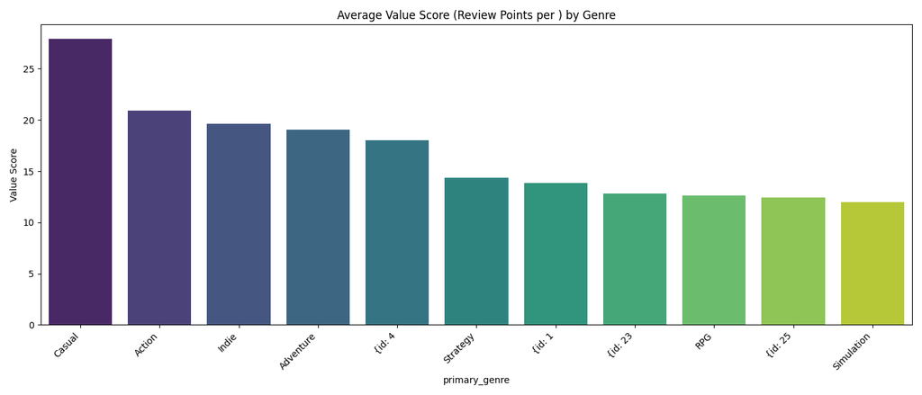

```python
# Question 3: Best Value Score
q3_df = df_main.groupby('primary_genre')['value_score'].mean().sort_values(ascending=False).reset_index()

plt.figure(figsize=(14, 6))
sns.barplot(data=q3_df, x='primary_genre', y='value_score', palette='viridis')
plt.title('Average Value Score (Review Points per $1) by Genre')
plt.xticks(rotation=45, ha='right')
plt.ylabel('Value Score')
plt.tight_layout()
plt.show()
```

### Question 4: How has average price trended across release years (2010 - 2025)?

**What this visual shows**: 15-year historical trend of Average Price (blue line), Median Price (green line), and Total Annual New Games (grey bars).

**Stakeholder Takeaway**: The platform is heavily commoditized. You cannot rely on store browsing alone; pre-launch marketing is mandatory.

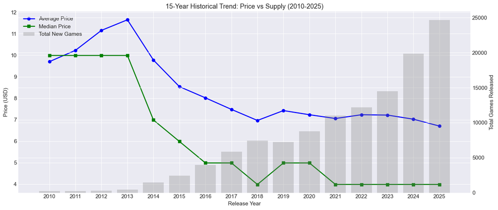

```python
# Question 4: Average price trend across years
yearly_stats = df.groupby('release_year').agg(
    avg_price=('price', 'mean'),
    median_price=('price', 'median'),
    game_count=('app_id', 'count')
).reset_index()

fig, ax1 = plt.subplots(figsize=(14, 6))

ax2 = ax1.twinx()
ax2.bar(yearly_stats['release_year'], yearly_stats['game_count'], color='gray', alpha=0.3, label='Total New Games')
ax1.plot(yearly_stats['release_year'], yearly_stats['avg_price'], color='blue', marker='o', linewidth=2, label='Average Price')
ax1.plot(yearly_stats['release_year'], yearly_stats['median_price'], color='green', marker='s', linewidth=2, label='Median Price')

ax1.set_xlabel('Release Year')
ax1.set_ylabel('Price (USD)')
ax2.set_ylabel('Total Games Released')
ax1.set_title('15-Year Historical Trend: Price vs Supply (2010-2025)')

# Combine legends
lines_1, labels_1 = ax1.get_legend_handles_labels()
lines_2, labels_2 = ax2.get_legend_handles_labels()
ax1.legend(lines_1 + lines_2, labels_1 + labels_2, loc='upper left')

plt.xticks(yearly_stats['release_year'])
plt.tight_layout()
plt.show()
```

## Section 2: Popularity & Player Engagement

### Question 5: Which genres have the highest ownership? Which are shrinking over recent years?

**What this visual shows**: Left: Lifetime average players per game by genre. Right: The sharp decline in sales per title from 2018 to 2025.

**Stakeholder Takeaway**: Build an active community with playable demos before launch to escape the crowded indie long tail.

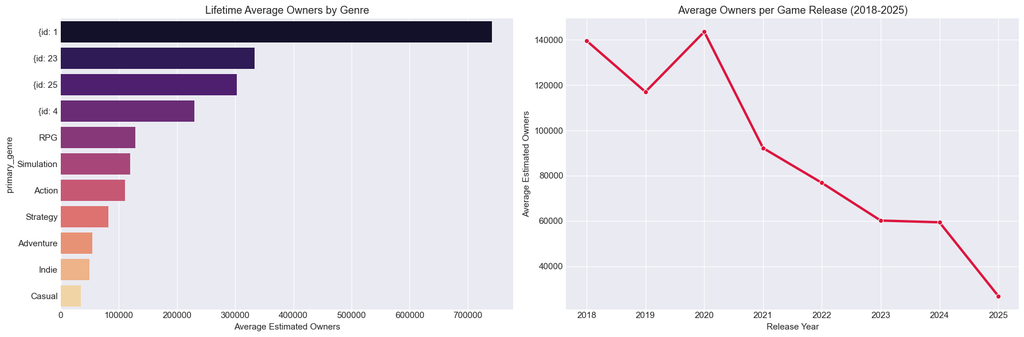

```python
# Question 5: Ownership by Genre and Trends
fig, (ax1, ax2) = plt.subplots(1, 2, figsize=(18, 6))

# Left: Lifetime average players
owners_genre = df_main.groupby('primary_genre')['highest_estimate_owner'].mean().sort_values(ascending=False).reset_index()
sns.barplot(data=owners_genre, x='highest_estimate_owner', y='primary_genre', ax=ax1, palette='magma')
ax1.set_title('Lifetime Average Owners by Genre')
ax1.set_xlabel('Average Estimated Owners')

# Right: Decline in sales per title
recent_years = df[(df['release_year'] >= 2018) & (df['release_year'] <= 2025)]
owners_year = recent_years.groupby('release_year')['highest_estimate_owner'].mean().reset_index()
sns.lineplot(data=owners_year, x='release_year', y='highest_estimate_owner', marker='o', color='crimson', linewidth=3, ax=ax2)
ax2.set_title('Average Owners per Game Release (2018-2025)')
ax2.set_ylabel('Average Estimated Owners')
ax2.set_xlabel('Release Year')

plt.tight_layout()
plt.show()
```